# Claude Change Baseline Censoring

2025-04-21

```r
install.packages("remotes") # unless you have it already
remotes::install_github("jtextor/dagitty/r")
library(dagitty)
library(ggdag)
library(tidyverse)
```

Each approach uses the same core data generating model with a proportional treatment effect, where the treatment works better in patients with lower baseline scores.

## Randomized Controlled Trial With No Loss to Follow-Up

In this simulation:

- `severity` is a latent (unobserved) variable that affects:

1. Baseline scores (sicker patients have lower scores)
2. Treatment effect (treatment works better for sicker patients)

Note that in this model severity is not affected by treatment or time. It is set at baseline for each patient and remains the same for each time period.

The Causal DAG for this data generating model is shown below.

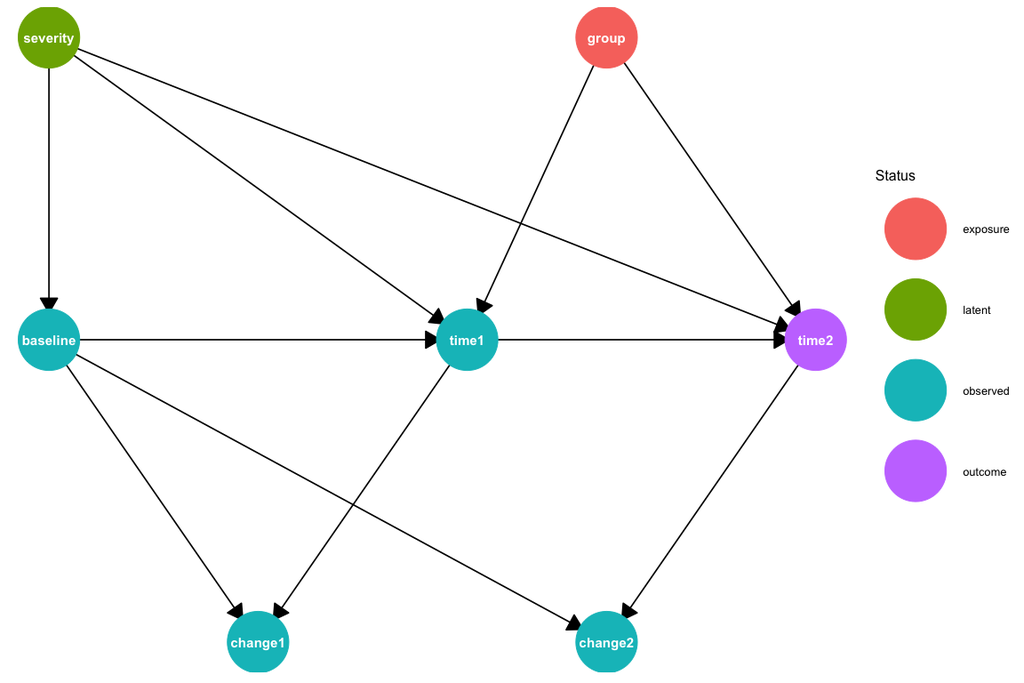

```r
# Create the DAG using dagify
dagRCT <- dagify(
  baseline ~ severity,
  time1 ~ baseline + group + severity,
  change1 ~ baseline + time1,
  time2 ~ group + time1 + severity,
  change2 ~ baseline + time2,
  exposure = "group",
  outcome = "time2",
  coords = data.frame(
    name = c("baseline", "severity", "group", "time1", "change1", "time2", "change2"),
    x = c(0, 0, 4, 3, 1.5, 5.5, 4),
    y = c(1, 2, 2, 1, 0, 1, 0)
  )
)

# Change status of severity to indicate that it is a latent variable
latents(dagRCT) = "severity"

# Convert the dagitty graph to a ggdag group for prettier printing
tidy_dagRCT <- tidy_dagitty(dagRCT)

# Plot with custom node shapes
# Get the status (exposure, outcome) information and set variables without a status to "observed"
status_data <- ggdag_status(tidy_dagRCT)$data %>% mutate(status = ifelse(is.na(status), "observed", as.character(status)))

#status_data <- status_data %>% mutate(gstatus = as.character(status), gstatus = ifelse(name == "censored", "adjusted", as.character(status)),
#                                      gstatus = factor(gstatus,levels = c(levels(status), "adjusted")))

# Plot with custom node shapes while preserving status coloring
ggplot(status_data, aes(x = x, y = y, xend = xend, yend = yend)) +
  geom_dag_edges(arrow_directed = grid::arrow(length = unit(0.5, "cm"), type = "closed")) +
  geom_dag_point(aes(color = status), size = 24) +
  geom_dag_text(color = "white") +
  scale_shape_manual(values = c(circle = 16, square = 15), guide = "none") +
  scale_color_discrete(name = "Status", na.value = "grey50") +
  theme_dag() +
  theme(legend.position = "right")
```

```r
NA
NA
```

Now let’s simulate data for the RCT.

```r
# Set seed for reproducibility
set.seed(124)

# Simulate data for demonstration
# 150 participants, 2 groups (treatment and control)
n <- 150
group <- rep(c(0, 1), each = n/2)  # 0 = control, 1 = treatment

# Generate baseline scores (similar for both groups)
baseline <- rnorm(n, mean = 50, sd = 10)

# Add a latent "severity" variable that affects baseline score
severity <- rnorm(n, mean = 0, sd = 1)

# Adjust baseline by severity (sicker patients have lower baseline scores)
baseline <- baseline - 5 * severity

# Generate follow-up scores with proportional effects
prop_effect1 <- 0.20  # 20% improvement at time1 for treatment group
prop_effect2 <- 0.15  # Additional 15% improvement at time2 for treatment group

# Calculate time1 values - true effect is proportional to baseline
# The treatment also has a stronger effect for patients with higher severity
time1 <- vector("numeric", n)
for (i in 1:n) {
  if (group[i] == 1) {
    # Treatment group: effect is proportional to baseline and increased by severity
    effect_modifier <- 1 + prop_effect1 + 0.1 * severity[i]
    time1[i] <- baseline[i] * effect_modifier + rnorm(1, mean = 0, sd = 3)
  } else {
    # Control group: small random change
    time1[i] <- baseline[i] + rnorm(1, mean = 0, sd = 3)
  }
}

# Calculate time2 values
time2 <- vector("numeric", n)
for (i in 1:n) {
  if (group[i] == 1) {
    # Treatment group: additional effect proportional to time1
    effect_modifier <- 1 + prop_effect2 + 0.05 * severity[i]
    time2[i] <- time1[i] * effect_modifier + rnorm(1, mean = 0, sd = 3)
  } else {
    # Control group: small random change
    time2[i] <- time1[i] + rnorm(1, mean = 0, sd = 3)
  }
}

# Create data frame
data <- data.frame(
  id = 1:n,
  group = factor(group, labels = c("Control", "Treatment")),
  baseline = baseline,
  time1 = time1,
  time2 = time2,
  severity = severity  # Include the latent severity variable
)

# Create change scores for the full dataset
data$change1 <- data$time1 - data$baseline
data$change2 <- data$time2 - data$baseline
data
```

| id | group | baseline | time1 | time2 | severity | change1 | change2 |
| --- | --- | --- | --- | --- | --- | --- | --- |
| 1 | Control | 39.09145 | 38.94449 | 43.17731 | -0.588431009 | -0.1469614 | 4.0858583 |
| 2 | Control | 57.19560 | 59.86716 | 59.32464 | -1.362473104 | 2.6715660 | 2.1290384 |
| 3 | Control | 44.61789 | 53.04918 | 51.18633 | -0.449637942 | 8.4312943 | 6.5684461 |
| 4 | Control | 55.33969 | 56.32246 | 51.88690 | -0.643325032 | 0.9827697 | -3.4527889 |
| 5 | Control | 66.80911 | 63.67679 | 61.39699 | -0.510745552 | -3.1323220 | -5.4121152 |
| 6 | Control | 56.15879 | 53.78891 | 53.34083 | 0.257202011 | -2.3698772 | -2.8179566 |
| 7 | Control | 59.10007 | 59.69455 | 60.80526 | -0.419555448 | 0.5944821 | 1.7051860 |
| 8 | Control | 52.46759 | 52.00316 | 49.52693 | -0.952227655 | -0.4644337 | -2.9406661 |
| 9 | Control | 49.40897 | 46.66109 | 42.28769 | 0.512393405 | -2.7478818 | -7.1212814 |
| 10 | Control | 70.79288 | 67.86056 | 62.61067 | -1.744267685 | -2.9323205 | -8.1822065 |

[output cut: 140 more lines]

For publication ready tables, we can use gtsummary. Here is the cannonical Table 1:

```r
library(gtsummary)
table1 <- data |> tbl_summary()
table1
```

| **Characteristic** | **N = 150**<sup>1</sup> |
| --- | --- |
| id | 76 (38, 113) |
| group |  |
| Control | 75 (50%) |
| Treatment | 75 (50%) |
| baseline | 50 (43, 57) |
| time1 | 54 (46, 63) |
| time2 | 59 (49, 69) |
| severity | -0.08 (-0.66, 0.51) |
| change1 | 3 (0, 9) |
| change2 | 6 (0, 19) |

<sup>1</sup> Median (Q1, Q3); n (%)

And here is the Canonical Table 2. This shows a significant difference between `time2` for the treatment and control groups.

```r
table2 <- tbl_summary(data, by = group) |> add_p() |> bold_labels()
table2
```

| **Characteristic** | **Control** N = 75<sup>1</sup> | **Treatment** N = 75<sup>1</sup> | **p-value**<sup>2</sup> |
| --- | --- | --- | --- |
| id | 38 (19, 57) | 113 (94, 132) | <0.001 |
| baseline | 50 (42, 56) | 50 (44, 58) | 0.6 |
| time1 | 51 (43, 57) | 61 (52, 68) | <0.001 |
| time2 | 50 (42, 58) | 69 (59, 79) | <0.001 |
| severity | -0.23 (-0.69, 0.51) | 0.02 (-0.61, 0.58) | 0.3 |
| change1 | 0 (-3, 2) | 9 (6, 13) | <0.001 |
| change2 | 0 (-3, 2) | 19 (11, 24) | <0.001 |

<sup>1</sup> Median (Q1, Q3)  
<sup>2</sup> Wilcoxon rank sum test

While there is only one measured covariate here (`baseline`) a covariate balance plot showing the standardized mean differences between covariates in the treated and untreated groups (treatment mean - control mean). Here, we include the latent variable `severity`. Even though we have an RCT, both covariates are skewed to the right.

```r
library(cobalt)
unadjcov <- bal.tab(group ~ baseline + severity, data = data, thresholds = c(m = .1))
```

```
Note: `s.d.denom` not specified; assuming "pooled".
```

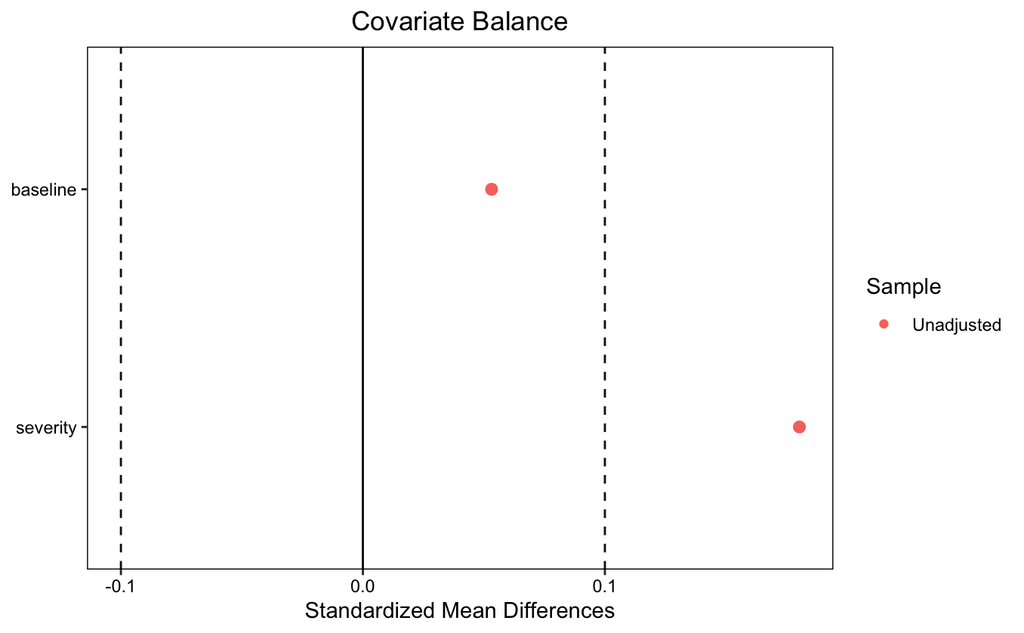

```r
love.plot(unadjcov, stars = "std", thresholds = c(m = .1))
```

There is some controversy over how to measure total effect of a treatment on change from baseline. If the baseline values of the treatment and control group are balanced, then an unbiased average treatment effect is just the mean of `time2` for those in the treatment group minus the mean for those in the control group. In an RCT with sufficient sample size, the baselines are expected to be balanced. Let’s check our data:

```r
data %>% group_by(group) %>% summarize(meanBaseline = mean(baseline))
```

| group | meanBaseline |
| --- | --- |
| Control | 49.95402 |
| Treatment | 50.48501 |

With the relatively small sample size, the baseline means are close, but not perfectly balanced. This could bias our effect estimate if we simply use the difference in means of `time2` between Treatment and Control. The means of `time2` for the Control and Treatment groups are:

```r
means <- data %>% group_by(group) %>% summarize(mean = mean(time2))
means
```

| group | mean |
| --- | --- |
| Control | 49.65727 |
| Treatment | 68.67236 |

Subtracting these to get the average treatment effect is:

```r
filter(means, group=="Treatment")$mean - filter(means, group=="Control")$mean
```

```
[1] 19.01509
```

We can also do a t-test to test for difference in means for `time2` between the treatment and control groups:

```r
t.test(time2 ~ group, data = data)
```

```
    Welch Two Sample t-test

data:  time2 by group
t = -9.1172, df = 128.09, p-value = 1.361e-15
alternative hypothesis: true difference in means between group Control and group Treatment is not equal to 0
95 percent confidence interval:
 -23.14184 -14.88834
sample estimates:
  mean in group Control mean in group Treatment
               49.65727                68.67236
```

Here, we see that the means are statistically significantly different.

If the baseline values are unbalanced, the effect estimate of the difference in means of `time2` will be biased. This is why many analysts recommend always using analysis of covariance (ANCOVA) where the outcome is regressed on the treatment and adjusted for the baseline value:

```r
res <- lm(time2 ~ group + baseline)
summary(res)
```

```
Call:
lm(formula = time2 ~ group + baseline)

Residuals:
     Min       1Q   Median       3Q      Max
-18.7101  -3.9017   0.4222   3.8035  26.5506

Coefficients:
            Estimate Std. Error t value Pr(>|t|)
(Intercept) -3.34995    3.05846  -1.095    0.275
group       18.45164    1.16948  15.778   <2e-16 ***
baseline     1.06112    0.05895  18.001   <2e-16 ***
---
Signif. codes:  0 ‘***’ 0.001 ‘**’ 0.01 ‘*’ 0.05 ‘.’ 0.1 ‘ ’ 1

Residual standard error: 7.159 on 147 degrees of freedom
Multiple R-squared:  0.8002,    Adjusted R-squared:  0.7974
F-statistic: 294.3 on 2 and 147 DF,  p-value: < 2.2e-16
```

We can use gtsummary for a nicer view of the results:

```r
tbl_regression(res, estimate_fun = purrr::partial(style_ratio, digits = 2))
```

| **Characteristic** | **Beta** | **95% CI** | **p-value** |
| --- | --- | --- | --- |
| group | 18.5 | 16.1, 20.8 | <0.001 |
| baseline | 1.06 | 0.94, 1.18 | <0.001 |

Abbreviation: CI = Confidence Interval

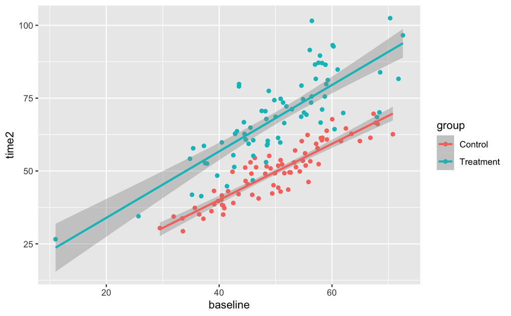

```r
ggplot(data, aes(x = baseline, y = time2, color = group)) + geom_point() +
  geom_smooth(method = lm)
```

Recall that the treatment effect in this model is proportional to the baseline value and increased by `severity`, a latent variable. The average treatment effect reported in the analysis above is the average across all baseline values in the model.

## Simulate proportional treatment effect on change from baseline in an RCT with censoring

For data with censoring and proportional treatment effects:

This simulation is identical to the one above, but with some subjects dropping out of the study prior to time2 being measured. Changes noted in bold.

- `severity` is latent variable that affects:

1. Baseline scores (sicker patients have lower scores)
2. Treatment effect (treatment works better for sicker patients)
3. **Censoring probability (sicker patients more likely to drop out)**

- **Treatment group participants are less likely to be censored**

**- Participants with less improvement are more likely to be censored**

The Causal DAG for this data generating model is shown below.

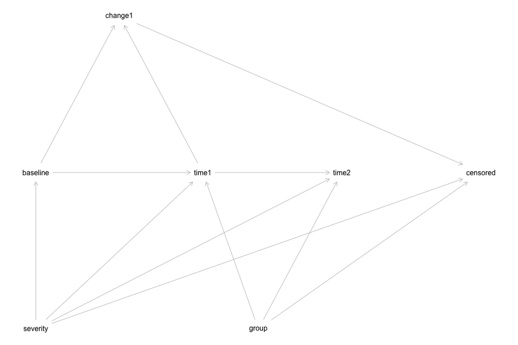

```r
library(dagitty)
library(ggdag)
library(tidyverse)
# Create the DAG using dagify
dag1 <- dagify(
  baseline ~ severity,
  time1 ~ baseline + group + severity,
  change1 ~ baseline + time1,
  censored ~ change1 + group + severity,
  time2 ~ group + time1 + severity,
  exposure = "group",
  outcome = "time2",
  coords = data.frame(
    name = c("baseline", "severity", "group", "time1", "change1", "censored", "time2"),
    x = c(0, 0, 4, 3, 1.5, 8, 5.5),
    y = c(1, 2, 2, 1, 0, 1, 1)
  )
)

# Indicate that `censored` is adjusted since we only have data for patients who are not censored, censored is forced to equal 0

adjustedNodes(dag1) <- "censored"
plot(dag1)
```

```r
#List all paths from treatment `group` to outcome `time2`
# `paths` currently ignores the adjusted nodes when determining which paths are open, so we have to specify adjusted nodes in the call
paths(dag1, Z = adjustedNodes(dag1))
```

```
$paths
 [1] "group -> censored <- change1 <- baseline -> time1 -> time2"
 [2] "group -> censored <- change1 <- baseline -> time1 <- severity -> time2"
 [3] "group -> censored <- change1 <- baseline <- severity -> time1 -> time2"
 [4] "group -> censored <- change1 <- baseline <- severity -> time2"
 [5] "group -> censored <- change1 <- time1 -> time2"
 [6] "group -> censored <- change1 <- time1 <- baseline <- severity -> time2"
 [7] "group -> censored <- change1 <- time1 <- severity -> time2"
 [8] "group -> censored <- severity -> baseline -> change1 <- time1 -> time2"
 [9] "group -> censored <- severity -> baseline -> time1 -> time2"
[10] "group -> censored <- severity -> time1 -> time2"
[11] "group -> censored <- severity -> time2"
[12] "group -> time1 -> change1 -> censored <- severity -> time2"
[13] "group -> time1 -> change1 <- baseline <- severity -> time2"
[14] "group -> time1 -> time2"
[15] "group -> time1 <- baseline -> change1 -> censored <- severity -> time2"
[16] "group -> time1 <- baseline <- severity -> time2"
[17] "group -> time1 <- severity -> time2"
[18] "group -> time2"

$open
 [1] TRUE TRUE TRUE TRUE TRUE TRUE TRUE TRUE TRUE TRUE TRUE TRUE TRUE TRUE TRUE TRUE TRUE TRUE
```

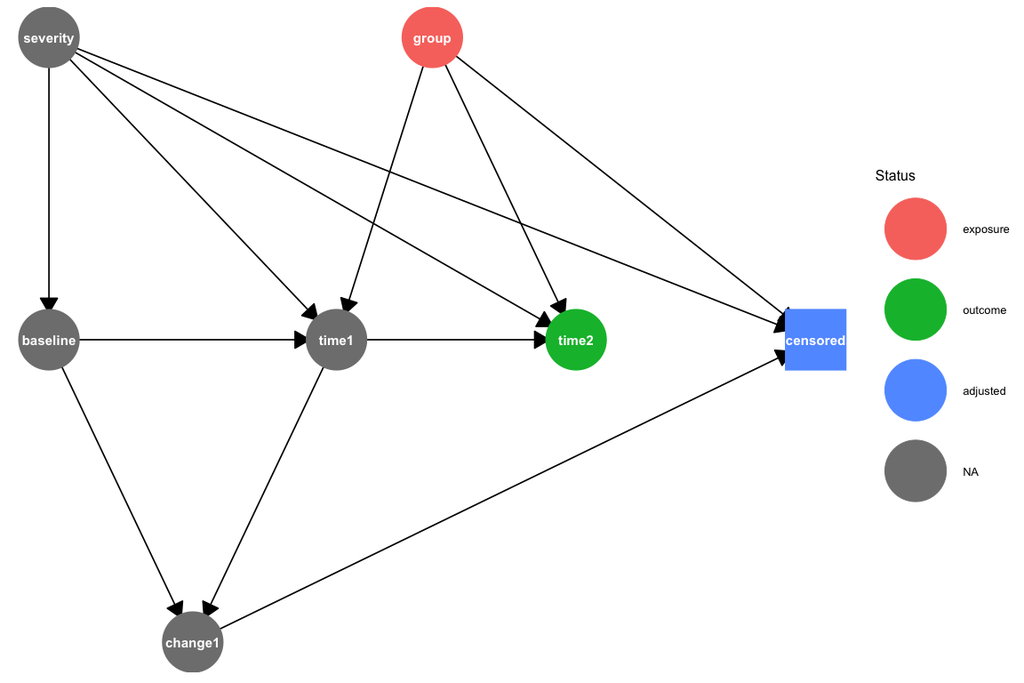

```r
# Print the adjustment sets (if any)
adjustmentSets(dag1)


tidy_dag1 <- tidy_dagitty(dag1) %>% mutate(shape = ifelse(name == "censored", "square", "circle"))

# Indicate that `censored` is adjusted for in this model
tidy_dag1 <- adjust_for(tidy_dag1, "censored")


# Plot with custom node shapes
# Get the status (exposure, outcome) information
status_data <- ggdag_status(tidy_dag1)$data
status_data <- status_data %>% mutate(gstatus = as.character(status), gstatus = ifelse(name == "censored", "adjusted", as.character(status)),
                                      gstatus = factor(gstatus,levels = c(levels(status), "adjusted")))

# Plot with custom node shapes while preserving status coloring
ggplot(status_data, aes(x = x, y = y, xend = xend, yend = yend)) +
  geom_dag_edges(arrow_directed = grid::arrow(length = unit(0.5, "cm"), type = "closed")) +
  geom_dag_point(aes(color = gstatus, shape = shape), size = 24) +
  geom_dag_text(color = "white") +
  scale_shape_manual(values = c(circle = 16, square = 15), guide = "none") +
  scale_color_discrete(name = "Status", na.value = "grey50") +
  theme_dag() +
  theme(legend.position = "right")
```

```r
NA
NA
NA
```

The `censored` variable is shown with a square around it to indicate that by analyzing only uncensored patients, `censored` is adjusted for in the analysis. Since all arrows point into `censored`, any path from treatment `group` to effect `time2` that includes `censored` will transmit spurious association through `censored` unless the path is blocked at another point.

To see this, lets look at all paths (causal and non-causal) from `group` to `time2`. A causal path is one in which arrows point from the treatment `group` to the outcome `time2`. Noncausal paths are those with at least one arrow pointing back toward the treatment.

```r
# `paths` currently ignores the adjusted nodes when determining which paths are open, so we have to specify the adjusted nodes in the call
paths(dag1, Z = adjustedNodes(dag1))
```

```
$paths
 [1] "group -> censored <- change1 <- baseline -> time1 -> time2"
 [2] "group -> censored <- change1 <- baseline -> time1 <- severity -> time2"
 [3] "group -> censored <- change1 <- baseline <- severity -> time1 -> time2"
 [4] "group -> censored <- change1 <- baseline <- severity -> time2"
 [5] "group -> censored <- change1 <- time1 -> time2"
 [6] "group -> censored <- change1 <- time1 <- baseline <- severity -> time2"
 [7] "group -> censored <- change1 <- time1 <- severity -> time2"
 [8] "group -> censored <- severity -> baseline -> change1 <- time1 -> time2"
 [9] "group -> censored <- severity -> baseline -> time1 -> time2"
[10] "group -> censored <- severity -> time1 -> time2"
[11] "group -> censored <- severity -> time2"
[12] "group -> time1 -> change1 -> censored <- severity -> time2"
[13] "group -> time1 -> change1 <- baseline <- severity -> time2"
[14] "group -> time1 -> time2"
[15] "group -> time1 <- baseline -> change1 -> censored <- severity -> time2"
[16] "group -> time1 <- baseline <- severity -> time2"
[17] "group -> time1 <- severity -> time2"
[18] "group -> time2"

$open
 [1] TRUE TRUE TRUE TRUE TRUE TRUE TRUE TRUE TRUE TRUE TRUE TRUE TRUE TRUE TRUE TRUE TRUE TRUE
```

We see that there are 18 paths from `group` to `time2`. $open is a boolean list showing whether each path is open or closed. All of these paths are open and since many of these paths are noncausal “backdoor” paths, meaning the arrows do not all point from `group` to `time2` this means that if we measure the association between `group` and `time2` in the data, that association is likely to exhibit bias from confounding. For example, paths 1 through 11 are all backdoor paths that go through `censored`. A collider is a variable on a path in which both arrows point toward it. As you can see, `censored` is a collider on every path it appears in. Colliders block association when they are not adjusted, but allow association to flow and bias the analysis when they are adjusted.

To properly measure the total causal effect of `group` on `time2` we need to measure the association that flows through all paths that point from `group` to `time2`. Let’s use `paths` to list only the causal paths:

```r
paths(dag1, Z = adjustedNodes(dag1), directed = TRUE)
```

```
$paths
[1] "group -> time1 -> time2" "group -> time2"

$open
[1] TRUE TRUE
```

There are two causal paths, both open. To measure the total causal effect, we need to block the non-causal open paths by adjusting for variables, if possible. We can use `ggdag` to list the adjustment sets for the total causal effect of `group` on `time2`. This returns nothing because there is no way to adjust variables to block the open path caused through the collider `censored.`

```r
adjustmentSets(dag1, effect = "total")
```

We will use IP Weighting for censoring below, but before that, lets analyze this dataset as if there were no loss to follow-up.

# Same model with no loss to follow-up

The same data generating model above includes time2_all with outcome values for all patients. Without Censoring the Causal DAG for time2_all looks like this:

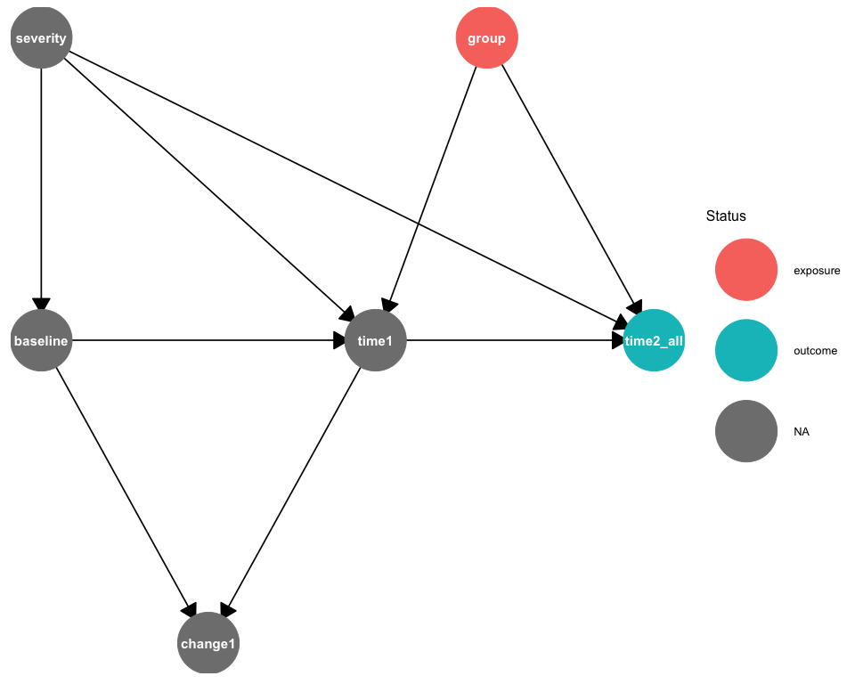

```r
library(dagitty)
library(ggdag)
library(tidyverse)
# Create the DAG using dagitify
dag_noloss <- dagify(
  baseline ~ severity,
  time1 ~ baseline + group + severity,
  change1 ~ baseline + time1,
  time2_all ~ group + time1 + severity,
  exposure = "group",
  outcome = "time2_all",
  coords = data.frame(
    name = c("baseline", "severity", "group", "time1", "change1", "censored", "time2_all"),
    x = c(0, 0, 4, 3, 1.5, 8, 5.5),
    y = c(1, 2, 2, 1, 0, 1, 1)
  )
)

tidy_dag_noloss <- tidy_dagitty(dag_noloss)

# Plot with custom node shapes
# Get the status (exposure, outcome) information
status_data <- ggdag_status(tidy_dag_noloss)$data
status_data <- status_data %>% mutate(gstatus = as.character(status), gstatus = ifelse(name == "censored", "adjusted", as.character(status)),
                                      gstatus = factor(gstatus,levels = c(levels(status), "adjusted")))

# Plot with custom node shapes while preserving status coloring
ggplot(status_data, aes(x = x, y = y, xend = xend, yend = yend)) +
  geom_dag_edges(arrow_directed = grid::arrow(length = unit(0.5, "cm"), type = "closed")) +
  geom_dag_point(aes(color = gstatus), size = 24) +
  geom_dag_text(color = "white") +
  scale_shape_manual(values = c(circle = 16, square = 15), guide = "none") +
  scale_color_discrete(name = "Status", na.value = "grey50") +
  theme_dag() +
  theme(legend.position = "right")
```

```r
NA
NA
NA
```

```r
# Load required libraries
library(dagitty)
library(ggdag)
library(dplyr)
library(ggplot2)

# Define the DAG
dag1 <- dagitty('dag {
bb="0,0,1,1"
baseline [pos="0.348,0.542"]
censored [adjusted,pos="0.931,0.499"]
change1 [pos="0.477,0.641"]
group [exposure,pos="0.343,0.368"]
severity [pos="0.348,0.449"]
time1 [pos="0.486,0.540"]
time2 [outcome,pos="0.605,0.539"]
baseline -> change1
baseline -> time1
change1 -> censored
group -> censored
group -> time1
group -> time2
severity -> baseline
severity -> censored
severity -> time1
severity -> time2
time1 -> change1
time1 -> time2
}'
)

plot(dag1)
```

## Generate Data According to the Two Causal DAGs Above

```r
# Install and load required packages
# Uncomment to install packages if needed
# install.packages(c("lavaan", "semPlot", "tidyverse", "psych"))

library(lavaan)
library(semPlot)
library(tidyverse)
library(psych)
# Set seed for reproducibility
set.seed(123)

# Simulate data for demonstration
# 150 participants, 2 groups (treatment and control)
n <- 150
group <- rep(c(0, 1), each = n/2)  # 0 = control, 1 = treatment

# Generate baseline scores (similar for both groups)
baseline <- rnorm(n, mean = 50, sd = 10)

# Add a latent "severity" variable that affects both baseline and censoring
# This creates the missing not at random (MNAR) scenario
severity <- rnorm(n, mean = 0, sd = 1)

# Adjust baseline by severity (sicker patients have lower baseline scores)
baseline <- baseline - 5 * severity

# Generate follow-up scores with proportional effects
prop_effect1 <- 0.20  # 20% improvement at time1 for treatment group
prop_effect2 <- 0.15  # Additional 15% improvement at time2 for treatment group

# Calculate time1 values - true effect is proportional to baseline
# The treatment also has a stronger effect for patients with higher severity
time1 <- vector("numeric", n)
for (i in 1:n) {
  if (group[i] == 1) {
    # Treatment group: effect is proportional to baseline and increased by severity
    effect_modifier <- 1 + prop_effect1 + 0.1 * severity[i]
    time1[i] <- baseline[i] * effect_modifier + rnorm(1, mean = 0, sd = 3)
  } else {
    # Control group: small random change
    time1[i] <- baseline[i] + rnorm(1, mean = 0, sd = 3)
  }
}

# Calculate time2 values
time2 <- vector("numeric", n)
for (i in 1:n) {
  if (group[i] == 1) {
    # Treatment group: additional effect proportional to time1
    effect_modifier <- 1 + prop_effect2 + 0.05 * severity[i]
    time2[i] <- time1[i] * effect_modifier + rnorm(1, mean = 0, sd = 3)
  } else {
    # Control group: small random change
    time2[i] <- time1[i] + rnorm(1, mean = 0, sd = 3)
  }
}

# Save time2 values prior to censoring to create a model without censoring
time2_all <- time2

# Generate censoring indicators
# Higher probability of censoring (dropout) for:
# 1. Sicker patients (higher severity)
# 2. Control group participants (treatment has benefit that keeps people engaged)
# 3. Those with smaller improvements from baseline to time1

# Calculate change from baseline to time1
change_time1 <- time1 - baseline

# Calculate censoring probabilities
# Logit model for censoring
logit_censoring <- -2 +
                   1.5 * severity +                # Sicker patients more likely to drop out
                   -0.5 * group +                 # Treatment group less likely to drop out
                   -0.05 * change_time1           # Those improving less likely to drop out

# Convert to probability
p_censored <- 1 / (1 + exp(-logit_censoring))

# Generate censoring indicator (1 = censored/dropped out, 0 = observed)
censored <- rbinom(n, 1, p_censored)

# Apply censoring to the data (set values to NA)
time2[censored == 1] <- NA

# Create data frame
data <- data.frame(
  id = 1:n,
  group = factor(group, labels = c("Control", "Treatment")),
  baseline = baseline,
  time1 = time1,
  time2 = time2,
  time2_all = time2_all,
  severity = severity,  # Include the latent severity variable
  censored = censored    # Include the censoring indicator
)

# Create change scores for the full dataset
data$change1 <- data$time1 - data$baseline
data$change2 <- data$time2 - data$baseline
data
```

| id | group | baseline | time1 | time2 | time2_all | severity | censored | change1 | change2 |
| --- | --- | --- | --- | --- | --- | --- | --- | --- | --- |
| 1 | Control | 40.45655 | 38.31082 | NA | 42.60203 | 0.78773885 | 1 | -2.14572656 | NA |
| 2 | Control | 43.85301 | 41.59495 | NA | 44.73483 | 0.76904224 | 1 | -2.25806690 | NA |
| 3 | Control | 63.92607 | 61.11045 | 62.41632 | 62.41632 | 0.33220258 | 0 | -2.81561611 | -1.5097493 |
| 4 | Control | 55.74697 | 52.58943 | 54.73496 | 54.73496 | -1.00837661 | 0 | -3.15753984 | -1.0120046 |
| 5 | Control | 51.89014 | 50.57866 | 53.33019 | 53.33019 | -0.11945261 | 0 | -1.31147860 | 1.4400462 |
| 6 | Control | 68.55263 | 69.54616 | NA | 61.56340 | -0.28039534 | 1 | 0.99353752 | NA |
| 7 | Control | 51.79421 | 45.75158 | 49.08241 | 49.08241 | 0.56298953 | 0 | -6.04263149 | -2.7118002 |
| 8 | Control | 39.21158 | 39.84752 | 38.39256 | 38.39256 | -0.37243876 | 0 | 0.63594130 | -0.8190215 |
| 9 | Control | 38.24660 | 41.95663 | NA | 42.64848 | 0.97697339 | 1 | 3.71002514 | NA |
| 10 | Control | 47.41628 | 53.52901 | 52.64353 | 52.64353 | -0.37458086 | 0 | 6.11272205 | 5.2272487 |

[output cut: 140 more lines]

# Analyze Ideal Dataset with no Loss to Follow-Up

Let’s analyze this dataset using the difference in group means:

```r
group_means <- data %>% group_by(group) %>% summarize(mean(time2_all))
group_means
```

| group | mean(time2_all) |
| --- | --- |
| Control | 50.43152 |
| Treatment | 66.81567 |

The average treatment effect when there is no loss to follow-up is and we do not adjust for baseline, we see:

```r
group_means %>% deframe %>% .[["Treatment"]] - group_means %>% deframe %>% .[["Control"]]
```

```
[1] 16.38415
```

Using ANCOVA we get:

```r
ideal <- glm(time2_all ~ baseline + group, data = data)
summary(ideal)
```

```
Call:
glm(formula = time2_all ~ baseline + group, data = data)

Coefficients:
               Estimate Std. Error t value Pr(>|t|)
(Intercept)     2.77655    2.34170   1.186    0.238
baseline        0.95396    0.04468  21.352   <2e-16 ***
groupTreatment 17.65259    1.00390  17.584   <2e-16 ***
---
Signif. codes:  0 ‘***’ 0.001 ‘**’ 0.01 ‘*’ 0.05 ‘.’ 0.1 ‘ ’ 1

(Dispersion parameter for gaussian family taken to be 37.66081)

    Null deviance: 32772.1  on 149  degrees of freedom
Residual deviance:  5536.1  on 147  degrees of freedom
AIC: 974.94

Number of Fisher Scoring iterations: 2
```

The effect estimate here is 17.65, which is higher than the difference in group means of 16.38.

When there is loss to follow-up, the näive approach to estimating the average treatment effect is to ignore patients who were censored, which means removing them from the data. The average treatment effect is then the mean outcome (time2) of the treated group minus the mean outcome (time2) of the untreated in the remaining patients. Here we return to using time2, which has missing values for censored patients.

```r
group_means_uncensored <- data %>% filter(censored == 0) %>% group_by(group) %>% summarize(mean(time2))
group_means_uncensored
```

| group | mean(time2) |
| --- | --- |
| Control | 52.66190 |
| Treatment | 66.69594 |

```r
group_means_uncensored %>% deframe %>% .[["Treatment"]] - group_means_uncensored %>% deframe %>% .[["Control"]]
```

```
[1] 14.03404
```

```r
model_naive <- lm(time2 ~ group + baseline,
                   data = subset(data, !is.na(time2)))
model_naive
```

```
Call:
lm(formula = time2 ~ group + baseline, data = subset(data, !is.na(time2)))

Coefficients:
   (Intercept)  groupTreatment        baseline
         4.506          16.862           0.929
```

This result is closer to the true result of 17.65

One appropriate way to analyze an RCT with censored patients is by using IP (Inverse Probability) weighting to adjust the data for the probability of remaining in the study. This creates a pseudo-population where the outcome for patients who were uncensored gets weighted by their inverse probability of staying in the study as calculated using baseline covariates.

To do this, we first use logistic regression to create a model that predicts whether a patient will be censored based on group (the treatment) and baseline HBA1C.

```r
# Model for censoring process - modeling factors affecting dropout
model_censoring <- glm(censored ~ group + baseline + time1,
                      data = data,
                      family = binomial(link = "logit"))

summary(model_censoring)
```

```
Call:
glm(formula = censored ~ group + baseline + time1, family = binomial(link = "logit"),
    data = data)

Coefficients:
                Estimate Std. Error z value Pr(>|z|)
(Intercept)     2.179932   1.285029   1.696   0.0898 .
groupTreatment -1.747864   0.954461  -1.831   0.0671 .
baseline       -0.077423   0.079859  -0.969   0.3323
time1           0.002417   0.073945   0.033   0.9739
---
Signif. codes:  0 ‘***’ 0.001 ‘**’ 0.01 ‘*’ 0.05 ‘.’ 0.1 ‘ ’ 1

(Dispersion parameter for binomial family taken to be 1)

    Null deviance: 114.000  on 149  degrees of freedom
Residual deviance:  97.511  on 146  degrees of freedom
AIC: 105.51

Number of Fisher Scoring iterations: 6
```

The model for censoring is consistent with the data generating process in which there is a Higher probability of censoring (dropout) for:

1. Sicker patients (higher severity)
2. Control group participants (treatment has benefit that keeps people engaged)
3. Those with smaller improvements from baseline to time1

Now we can predict the probability of remaining in the study (not being censored) by using the regression results on each patient in the study and calculating 1 - p(censored) Look at the probability of remaining in the study to convince yourself that the model is producing appropriate results. For example, patients in the treatment group are more likely to remain in the study, as expected.

```r
data$p_observed <- 1 - predict(model_censoring, type = "response")
data
```

[output not shown]

[output cut: 140 more lines]

We can compare covariates based on treatment group. Notice that those in the control group are more likely to be censored and therefore have a lower probability of being observed at time2:

```r
table2 <- tbl_summary(data, by = group) |> add_p() |> bold_labels()
table2
```

[output not shown]

<sup>1</sup> Median (Q1, Q3); n (%)  
<sup>2</sup> Wilcoxon rank sum test; Pearson’s Chi-squared test

Now we add the IP weights to the data

```r
# Create weights as inverse of probability of being observed
data$ipw <- 1 / data$p_observed
```

Finally, we can do a second regression with the IP weights to estimate the average treatment effect:

```r
# Weighted analysis
model_ipw <- glm(time2 ~ group + baseline,
                data = subset(data, !is.na(time2)),
                weights = ipw)

summary(model_ipw)
```

```
Call:
glm(formula = time2 ~ group + baseline, data = subset(data, !is.na(time2)),
    weights = ipw)

Coefficients:
               Estimate Std. Error t value Pr(>|t|)
(Intercept)     4.26106    2.51950   1.691   0.0932 .
groupTreatment 16.87712    1.04851  16.096   <2e-16 ***
baseline        0.93346    0.04761  19.605   <2e-16 ***
---
Signif. codes:  0 ‘***’ 0.001 ‘**’ 0.01 ‘*’ 0.05 ‘.’ 0.1 ‘ ’ 1

(Dispersion parameter for gaussian family taken to be 40.56733)

    Null deviance: 28883.2  on 130  degrees of freedom
Residual deviance:  5192.6  on 128  degrees of freedom
AIC: 845.73

Number of Fisher Scoring iterations: 2
```

FInally we use this model and G-Computation to create the counterfactuals (the outcomes when treated and untreaded) for all patients.

To do this, we copy the dataset, set all patients to the Treatment group, then use the model to predict time2_1. Then we do the same for the control to create time2_0. The difference in means give us the effect.

```r
# Copy dataset
datap <- data

# Set all patients to Treatment
datap <- datap %>% mutate(group = "Treatment")

# Predict and store time2_1
time2_1 <- predict(model_ipw, newdata = datap, type = "response")

# Set all patients to Control
datap <- datap %>% mutate(group = "Control")

# Predict time2_0 (for control)
time2_0 <- predict(model_ipw, newdata = datap, type = "response")

# Find the difference in means
mean(time2_1) - mean(time2_0)
```

```
[1] 16.87712
```

# Analyzing Censored Dataset

```r
# Create interaction term for the model - do this BEFORE creating the uncensored subset
data$group_numeric <- as.numeric(data$group) - 1  # Convert to 0/1
data$baseline_by_group <- data$baseline * data$group_numeric

# Create uncensored subset - AFTER creating all derived variables
data_uncensored <- subset(data, censored == 0)
print(paste("Number of censored observations:", sum(data$censored)))
print(paste("Proportion of censored observations:", mean(data$censored)))

# Basic visualization - compare baseline by censoring status
ggplot(data, aes(x = factor(censored), y = baseline, fill = group)) +
  geom_boxplot() +
  ggtitle("Baseline Scores by Group and Censoring Status") +
  xlab("Censored (1 = yes, 0 = no)") +
  ylab("Baseline Score")

# Create change scores
data$change1 <- data$time1 - data$baseline
data$change2 <- data$time2 - data$baseline

# Longitudinal plot with censoring indicated
data_long <- data %>%
  pivot_longer(cols = c(baseline, time1, time2),
               names_to = "time",
               values_to = "score") %>%
  mutate(time = factor(time, levels = c("baseline", "time1", "time2"),
                      labels = c("Baseline", "Time 1", "Time 2")))

# Add transparency based on censoring (censored data points are more transparent)
ggplot(data_long, aes(x = time, y = score, group = interaction(id, group),
                      color = group, alpha = factor(censored))) +
  geom_line() +
  scale_alpha_manual(values = c("0" = 1, "1" = 0.2), name = "Censored") +
  stat_summary(data = subset(data_long, !(time == "Time 2" & is.na(score))),
               aes(group = group), fun = mean, geom = "line", size = 1.5) +
  stat_summary(data = subset(data_long, !(time == "Time 2" & is.na(score))),
               aes(group = group), fun = mean, geom = "point", size = 3) +
  theme_minimal() +
  ggtitle("Change in Scores Over Time by Group (with Censoring)") +
  ylab("Score") +
  xlab("Measurement Time")

# Define SEM model for uncensored data
# We need a separate model because the censoring variable has no variance in the uncensored subset
model_uncens <- '
  # Latent variable for true change
  change =~ change1 + change2

  # Regression paths: group, baseline, and severity predict change
  # Group represents treatment effect
  # Baseline represents the proportional nature of the effect
  # Severity represents the hidden confounding variable
  change ~ group + baseline + severity

  # Allow residual correlation between time points
  change1 ~~ change2
'

# Fit the model using only uncensored data (creates bias)
fit_uncens <- sem(model_uncens, data = data_uncensored)
summary(fit_uncens, fit.measures = TRUE, standardized = TRUE)

# Model that ignores severity (misspecified)
model_misspec <- '
  # Latent variable for true change
  change =~ change1 + change2

  # Regression paths: only group and baseline predict change
  # Missing the severity variable (creates omitted variable bias)
  change ~ group + baseline

  # Allow residual correlation between time points
  change1 ~~ change2
'

# Fit the misspecified model with all data using FIML
fit_misspec <- sem(model_misspec, data = data, missing = "fiml")
summary(fit_misspec, fit.measures = TRUE, standardized = TRUE)

# Fit the misspecified model with uncensored data only (double bias)
fit_misspec_uncens <- sem(model_misspec, data = data_uncensored)
summary(fit_misspec_uncens, fit.measures = TRUE, standardized = TRUE)

# Compare treatment effect estimates across models
# We need to handle the case where some models may not have been successfully fit
treatmentEffect <- data.frame(
  Model = character(),
  Estimate = numeric(),
  stringsAsFactors = FALSE
)

# Extract treatment effect from model1
if(exists("fit_cens")) {
  idx <- which(parameterEstimates(fit_cens)$lhs == "change" &
               parameterEstimates(fit_cens)$rhs == "group")
  if(length(idx) > 0) {
    treatmentEffect <- rbind(treatmentEffect,
                          data.frame(Model = "Complete + Severity",
                                     Estimate = parameterEstimates(fit_cens)[idx, "est"]))
  }
}

# Extract from model with uncensored data + severity
if(exists("fit_uncens")) {
  idx <- which(parameterEstimates(fit_uncens)$lhs == "change" &
               parameterEstimates(fit_uncens)$rhs == "group")
  if(length(idx) > 0) {
    treatmentEffect <- rbind(treatmentEffect,
                          data.frame(Model = "Uncensored + Severity",
                                     Estimate = parameterEstimates(fit_uncens)[idx, "est"]))
  }
}

# Extract from misspecified model
if(exists("fit_misspec")) {
  idx <- which(parameterEstimates(fit_misspec)$lhs == "change" &
               parameterEstimates(fit_misspec)$rhs == "group")
  if(length(idx) > 0) {
    treatmentEffect <- rbind(treatmentEffect,
                          data.frame(Model = "Complete w/o Severity",
                                     Estimate = parameterEstimates(fit_misspec)[idx, "est"]))
  }
}

# Extract from misspecified model with uncensored data
if(exists("fit_misspec_uncens")) {
  idx <- which(parameterEstimates(fit_misspec_uncens)$lhs == "change" &
               parameterEstimates(fit_misspec_uncens)$rhs == "group")
  if(length(idx) > 0) {
    treatmentEffect <- rbind(treatmentEffect,
                          data.frame(Model = "Uncensored w/o Severity",
                                     Estimate = parameterEstimates(fit_misspec_uncens)[idx, "est"]))
  }
}

# Print the comparison table
print("Treatment Effect Estimates Across Models:")
print(treatmentEffect)

# This comparison table shows the bias introduced by analyzing only uncensored participants
# and by omitting important confounding variables from the model

# Alternative model with latent variables for each time point
# For proportional effects, we need interaction terms
model2 <- '
  # Latent variables for each time point
  baseline =~ 1*baseline
  followup1 =~ 1*time1
  followup2 =~ 1*time2

  # Regression paths from baseline to follow-ups
  followup1 ~ baseline
  followup2 ~ baseline + followup1

  # Effect of treatment on follow-ups
  # Direct effects of group
  followup1 ~ group
  followup2 ~ group

  # Interaction effects (proportional effects)
  # Create interaction term in the data first
'

# Alternative model with latent variables and missing data handling
model2_cens <- '
  # Latent variables for each time point - avoid name collisions with observed variables
  latent_baseline =~ 1*baseline
  latent_followup1 =~ 1*time1
  latent_followup2 =~ 1*time2

  # Regression paths from baseline to follow-ups
  latent_followup1 ~ latent_baseline
  latent_followup2 ~ latent_baseline + latent_followup1

  # Effect of treatment on follow-ups
  # Direct effects of group
  latent_followup1 ~ group
  latent_followup2 ~ group

  # Severity affects outcomes
  latent_baseline ~ severity
  latent_followup1 ~ severity
  latent_followup2 ~ severity

  # Censoring is related to severity and treatment
  censored ~ severity + group

  # Interaction effects (proportional effects)
  latent_followup1 ~ baseline_by_group
  latent_followup2 ~ baseline_by_group
'

# Create interaction term for the model if not already there
if(!"baseline_by_group" %in% names(data)) {
  data$group_numeric <- as.numeric(data$group) - 1  # Convert to 0/1
  data$baseline_by_group <- data$baseline * data$group_numeric
}

# Fit the censoring-aware model with FIML
fit2_cens <- sem(model2_cens, data = data, missing = "fiml")
summary(fit2_cens, fit.measures = TRUE, standardized = TRUE)

# Visualize the censoring-aware model
semPaths(fit2_cens, what = "est", fade = FALSE, residuals = FALSE,
         edge.label.cex = 0.8,
         title = FALSE,
         layout = "tree2")

# Create a simplified version for uncensored data only
model2_simple <- '
  # Latent variables for each time point - avoid name collisions
  latent_baseline =~ 1*baseline
  latent_followup1 =~ 1*time1
  latent_followup2 =~ 1*time2

  # Regression paths from baseline to follow-ups
  latent_followup1 ~ latent_baseline
  latent_followup2 ~ latent_baseline + latent_followup1

  # Effect of treatment on follow-ups
  # Direct effects of group
  latent_followup1 ~ group
  latent_followup2 ~ group

  # Interaction effects (proportional effects)
  latent_followup1 ~ baseline_by_group
  latent_followup2 ~ baseline_by_group
'

# Fit the simplified model with uncensored data only
# Check first that required variables exist in the dataset
print("Variables in data_uncensored:")
print(names(data_uncensored))

# Verify that baseline_by_group exists in the dataset
if("baseline_by_group" %in% names(data_uncensored)) {
  fit2_uncens <- sem(model2_simple, data = data_uncensored)
  summary(fit2_uncens, fit.measures = TRUE, standardized = TRUE)
} else {
  print("Error: baseline_by_group missing from data_uncensored")
  # Create it again just to be sure
  data_uncensored$group_numeric <- as.numeric(data_uncensored$group) - 1
  data_uncensored$baseline_by_group <- data_uncensored$baseline * data_uncensored$group_numeric

  # Now try fitting the model
  fit2_uncens <- sem(model2_simple, data = data_uncensored)
  summary(fit2_uncens, fit.measures = TRUE, standardized = TRUE)
}

# Interpretation
# For data with censoring and proportional treatment effects:
#
# In this simulation:
#
# 1. SELECTION BIAS MECHANISM:
#    - We created a "severity" latent variable that affects:
#      a) Baseline scores (sicker patients have lower scores)
#      b) Treatment effect (treatment works better for sicker patients)
#      c) Censoring probability (sicker patients more likely to drop out)
#    - Treatment group participants are less likely to be censored
#    - Participants with less improvement are more likely to be censored
#
# 2. BIAS IN THE TREATMENT EFFECT ESTIMATE:
#    - Complete model with severity included (fit_cens): Most accurate estimate
#    - Uncensored data with severity included (fit_uncens): Biased estimate
#      (typically underestimates treatment effect because sicker patients
#      who would benefit more are more likely to drop out)
#    - Models without severity (fit_misspec & fit_misspec_uncens): Biased due to
#      omitted variable bias (severity affects both censoring and outcomes)
#
# 3. THE BIASES INTERACT:
#    - Selection bias: Analyzing only uncensored participants
#    - Omitted variable bias: Not including severity variable
#    - The combined effect typically leads to underestimating treatment efficacy
#
# 4. PROPER HANDLING APPROACHES:
#    - Full Information Maximum Likelihood (FIML) for missing data
#    - Including all relevant confounders in the model
#    - Sensitivity analyses for different missing data mechanisms
#    - Inverse probability weighting to account for selection bias
#
# The comparison of treatment effect estimates across models shows how much
# the estimated effect changes when using different approaches, demonstrating
# the magnitude of bias from censoring and model misspecification.
```

[output not shown]

```r
# GLM Analysis for Treatment Effect with Censoring

# Assuming the data has already been generated as in the previous code
# and variables are in the 'data' dataframe

# 1. Naive GLM analysis ignoring censoring
# This ignores the missing data problem and just analyzes what is observed

# Model for time2 outcome, complete cases only
model_naive <- glm(time2 ~ group + baseline,
                  data = subset(data, !is.na(time2)),
                  family = gaussian())

# Summary of naive model
summary(model_naive)

# 2. Model for change from baseline
# Calculate absolute change and use as outcome
data$abs_change <- data$time2 - data$baseline

model_change <- glm(abs_change ~ group + baseline,
                   data = subset(data, !is.na(time2)),
                   family = gaussian())

summary(model_change)

# 3. Model for proportional change
# Calculate proportional change and use as outcome
data$prop_change <- (data$time2 - data$baseline) / data$baseline

model_prop_change <- glm(prop_change ~ group + baseline,
                        data = subset(data, !is.na(time2)),
                        family = gaussian())

summary(model_prop_change)

# 4. Model that includes severity (the hidden confounder)
model_with_severity <- glm(time2 ~ group + baseline + severity,
                         data = subset(data, !is.na(time2)),
                         family = gaussian())

summary(model_with_severity)

# 5. Model for censoring process - modeling factors affecting dropout
model_censoring <- glm(censored ~ group + baseline + severity,
                      data = data,
                      family = binomial(link = "logit"))

summary(model_censoring)

# 6. Inverse probability weighting to account for censoring
# First, predict probability of being observed (not censored)
data$p_observed <- 1 - predict(model_censoring, type = "response")

# Create weights as inverse of probability of being observed
data$ipw <- 1 / data$p_observed

# Weighted analysis
model_ipw <- glm(time2 ~ group + baseline,
                data = subset(data, !is.na(time2)),
                family = gaussian(),
                weights = ipw)

summary(model_ipw)

# 7. Model with interaction between baseline and treatment
model_interaction <- glm(time2 ~ group * baseline + severity,
                       data = subset(data, !is.na(time2)),
                       family = gaussian())

summary(model_interaction)

# 8. Compare treatment effect estimates across different models
# Extract coefficients for the treatment effect (group)
treatment_effects <- data.frame(
  Model = c(
    "Naive (Complete Cases)",
    "Change Score",
    "Proportional Change",
    "With Severity",
    "IPW for Censoring",
    "With Interaction"
  ),
  Estimate = c(
    coef(model_naive)["groupTreatment"],
    coef(model_change)["groupTreatment"],
    coef(model_prop_change)["groupTreatment"],
    coef(model_with_severity)["groupTreatment"],
    coef(model_ipw)["groupTreatment"],
    coef(model_interaction)["groupTreatment"]
  ),
  SE = c(
    summary(model_naive)$coefficients["groupTreatment", "Std. Error"],
    summary(model_change)$coefficients["groupTreatment", "Std. Error"],
    summary(model_prop_change)$coefficients["groupTreatment", "Std. Error"],
    summary(model_with_severity)$coefficients["groupTreatment", "Std. Error"],
    summary(model_ipw)$coefficients["groupTreatment", "Std. Error"],
    summary(model_interaction)$coefficients["groupTreatment", "Std. Error"]
  )
)

treatment_effects$Lower_CI <- treatment_effects$Estimate - 1.96 * treatment_effects$SE
treatment_effects$Upper_CI <- treatment_effects$Estimate + 1.96 * treatment_effects$SE

# Print comparison table
print(treatment_effects)

# 9. Visualization of treatment effects across models
library(ggplot2)

ggplot(treatment_effects, aes(x = Model, y = Estimate)) +
  geom_point(size = 3) +
  geom_errorbar(aes(ymin = Lower_CI, ymax = Upper_CI), width = 0.2) +
  coord_flip() +
  theme_minimal() +
  ggtitle("Treatment Effect Estimates Across Different GLM Models") +
  ylab("Estimated Treatment Effect") +
  xlab("")

# 10. Calculate marginal effects of treatment at different baseline values
# This shows how the treatment effect varies with baseline
# if(requireNamespace("margins", quietly = TRUE)) {
#   library(margins)
#
#   # For the interaction model
#   marg_effects <- margins(model_interaction,
#                          variables = "group",
#                          at = list(baseline = seq(min(data$baseline, na.rm = TRUE),
#                                                 max(data$baseline, na.rm = TRUE),
#                                                 length.out = 10)))
#
#   summary(marg_effects)
#
#   # Plot the marginal effects
#   plot(marg_effects)
# } else {
  # Manual calculation of marginal effects at different baseline values
  baseline_values <- seq(min(data$baseline, na.rm = TRUE),
                        max(data$baseline, na.rm = TRUE),
                        length.out = 10)

  # Extract coefficients
  b_group <- coef(model_interaction)["groupTreatment"]
  b_interaction <- coef(model_interaction)["groupTreatment:baseline"]

  # Calculate marginal effect at each baseline value
  marginal_effects <- data.frame(
    baseline = baseline_values,
    effect = b_group + b_interaction * baseline_values
  )

  # Plot the marginal effects
  ggplot(marginal_effects, aes(x = baseline, y = effect)) +
    geom_line() +
    geom_point() +
    theme_minimal() +
    ggtitle("Marginal Effect of Treatment at Different Baseline Values") +
    ylab("Treatment Effect") +
    xlab("Baseline Value")
#}

# 11. Calculate the total effect of treatment on time2
# For models without interaction, this is just the coefficient of group
# For models with interaction, we need to evaluate at the mean baseline

# Mean baseline value
mean_baseline <- mean(data$baseline, na.rm = TRUE)

# Total effect in interaction model
total_effect <- coef(model_interaction)["groupTreatment"] +
               coef(model_interaction)["groupTreatment:baseline"] * mean_baseline

cat("Total effect of treatment on time2 at mean baseline:", total_effect, "\n")

# 12. Predicted outcomes for treatment vs control
# Create prediction data for a range of baseline values
pred_data <- expand.grid(
  group = factor(c("Control", "Treatment"), levels = levels(data$group)),
  baseline = seq(min(data$baseline, na.rm = TRUE),
                max(data$baseline, na.rm = TRUE),
                length.out = 20),
  severity = mean(data$severity, na.rm = TRUE)  # Fix severity at mean
)

# Predictions from different models
pred_data$pred_naive <- predict(model_naive, newdata = pred_data, type = "response")
pred_data$pred_with_severity <- predict(model_with_severity, newdata = pred_data, type = "response")
pred_data$pred_interaction <- predict(model_interaction, newdata = pred_data, type = "response")

# Plot predictions
ggplot(pred_data, aes(x = baseline, y = pred_interaction, color = group)) +
  geom_line() +
  theme_minimal() +
  ggtitle("Predicted Time2 Values by Treatment Group and Baseline") +
  ylab("Predicted Time2") +
  xlab("Baseline Value") +
  scale_color_manual(values = c("blue", "red")) +
  theme(legend.title = element_blank())

# Additional analysis: Marginal effects for IPW interaction model

model_interaction_ipw <- glm(time2 ~ group * baseline + severity,
                           data = subset(data, !is.na(time2)),
                           family = gaussian(),
                           weights = ipw)

if(requireNamespace("margins", quietly = TRUE)) {
  library(margins)

  # Marginal effects for standard interaction model
  marg_effects_std <- margins(model_interaction,
                            variables = "group",
                            at = list(baseline = seq(min(data$baseline, na.rm = TRUE),
                                                   max(data$baseline, na.rm = TRUE),
                                                   length.out = 10)))

  # Marginal effects for IPW interaction model
  marg_effects_ipw <- margins(model_interaction_ipw,
                            variables = "group",
                            at = list(baseline = seq(min(data$baseline, na.rm = TRUE),
                                                   max(data$baseline, na.rm = TRUE),
                                                   length.out = 10)))

  # Combine for comparison
  marg_combined <- data.frame(
    baseline = attr(marg_effects_std, "at")$baseline,
    effect_std = summary(marg_effects_std)$AME,
    effect_ipw = summary(marg_effects_ipw)$AME
  )

  # Plot comparison of marginal effects
  ggplot(marg_combined) +
    geom_line(aes(x = baseline, y = effect_std, color = "Standard Model")) +
    geom_line(aes(x = baseline, y = effect_ipw, color = "IPW Model")) +
    geom_point(aes(x = baseline, y = effect_std, color = "Standard Model")) +
    geom_point(aes(x = baseline, y = effect_ipw, color = "IPW Model")) +
    theme_minimal() +
    ggtitle("Marginal Effect of Treatment at Different Baseline Values") +
    ylab("Treatment Effect") +
    xlab("Baseline Value") +
    scale_color_manual(values = c("blue", "red"), name = "Model Type")
} else {
  # Manual calculation for both models
  baseline_values <- seq(min(data$baseline, na.rm = TRUE),
                        max(data$baseline, na.rm = TRUE),
                        length.out = 10)

  # Extract coefficients for standard model
  b_group_std <- coef(model_interaction)["groupTreatment"]
  b_interaction_std <- coef(model_interaction)["groupTreatment:baseline"]

  # Extract coefficients for IPW model
  b_group_ipw <- coef(model_interaction_ipw)["groupTreatment"]
  b_interaction_ipw <- coef(model_interaction_ipw)["groupTreatment:baseline"]

  # Calculate marginal effects
  marginal_effects <- data.frame(
    baseline = baseline_values,
    effect_std = b_group_std + b_interaction_std * baseline_values,
    effect_ipw = b_group_ipw + b_interaction_ipw * baseline_values
  )

  # Plot comparison
  ggplot(marginal_effects) +
    geom_line(aes(x = baseline, y = effect_std, color = "Standard Model")) +
    geom_line(aes(x = baseline, y = effect_ipw, color = "IPW Model")) +
    geom_point(aes(x = baseline, y = effect_std, color = "Standard Model")) +
    geom_point(aes(x = baseline, y = effect_ipw, color = "IPW Model")) +
    theme_minimal() +
    ggtitle("Marginal Effect of Treatment at Different Baseline Values") +
    ylab("Treatment Effect") +
    xlab("Baseline Value") +
    scale_color_manual(values = c("blue", "red"), name = "Model Type")
}
```

[output not shown]

## Analyze non-censored version, including severity. When no patients are censored severity should not be needed.

```r
glm(formula = time2_all ~ group + baseline + severity, family = gaussian(),
    data = data)
```

# Removing severity from the model

```r
glm(formula = time2_all ~ group + baseline, family = gaussian(),
    data = data)
```

# Adding baseline as an interaction with treatment group

```r
glm(formula = time2_all ~ group*baseline, family = gaussian(),
    data = data)
```

## Analysis using stabilized inverse probability weights to adjust for censoring.

Treatment is randomized in this data, so no need to adjust for treatment assignment

```r
### Estimate stabilized inverse probability weights for censoring ###

# Fit a pooled logistic model that predicts the probability of remaining uncensored
# (not being lost to follow-up)
psc.denom <- glm(censored == 0 ~ group + baseline + severity ,
                family=binomial(link="logit"),
                data=data)
summary(psc.denom)

# Obtain predicted probabilities for the denominator
data$psc.denom <- predict(psc.denom, data, type="response")

# Fit model for the numerator of the stabilized weights
psc.num <- glm(censored==0 ~ group,
               family=binomial(link="logit"), data=data)
summary(psc.num)

# Estimate stabilized weights
data$psc.num <- predict(psc.num, data, type="response")

data <- data %>%
  group_by(id) %>%
  mutate(
    sw_c = cumprod(psc.num)/cumprod(psc.denom)
  ) %>%
  ungroup() %>%
  mutate(sw_c = ifelse(is.na(censored), 1, sw_c))


###  Min, 25th percentile, median, mean, SD, 75th percentile, and max: stabilized weights ###
summary(data$sw_c)
sd(data$sw_c)
```

Funk, Michele Jonsson, Daniel Westreich, Chris Wiesen, Til Stürmer, M. Alan Brookhart, and Marie Davidian. 2011. “Doubly Robust Estimation of Causal Effects.” *American Journal of Epidemiology* 173 (7): 761–67. https://doi.org/10.1093/aje/kwq439.

Tennant, Peter W G, Kellyn F Arnold, George T H Ellison, and Mark S Gilthorpe. 2021. “Analyses of ‘Change Scores’ Do Not Estimate Causal Effects in Observational Data.” *International Journal of Epidemiology* 51 (5): 1604–15. https://doi.org/10.1093/ije/dyab050.